# Correlaciones

#### 3.2.2 Simulación: variables sin relación

Vamos a volver a simular las dos variables $X \sim N(0, 0.5)$ e $Y \sim N(0, 0.5)$ que no tienen ningún tipo de relación (ni lineal ni no lineal entre ellas)

```r
set.seed(12345)
x <- rnorm(n = 1e6, mean = 0, sd = 0.5)
y <- rnorm(n = 1e6, mean = 0, sd = 0.5)
cor(x, y)
```

```
[1] -0.001707521
```

Ahora sí que pdoemos decir que, efectivamente, la **relación lineal es inexistente** ya que la **correlación es prácticamente nula**

#### 3.2.3 Simulación: variables sin relación lineal

Simulamos de nuevo una variable $X$ de manera aleatoria y otra variable $Y$ tal que $Y = X^2$

```r
set.seed(12345)
x <- rnorm(n = 1e6, mean = 0, sd = 0.5)
y <- x^2
cor(x, y)
```

```
[1] 0.001639215
```

Aunque haya una **relación de dependencia perfecta** entre X e Y (una función que las relaciona), **la correlación vuelve a ser prácticamente nula**.

#### 3.2.4 Simulación: variables con relación lineal

Y vamos a volver a simular dos variables con relación lineal

```r
set.seed(12345)
x <- rnorm(n = 1e6, mean = 0, sd = 0.5)
y <- 2*x
cor(x, y)
```

```
[1] 1
```

#### 3.2.5 Simulación con ruido

¿Y si a la anterior relación lineal le incorporamos **ruido**, con una varianza cada vez más grande?

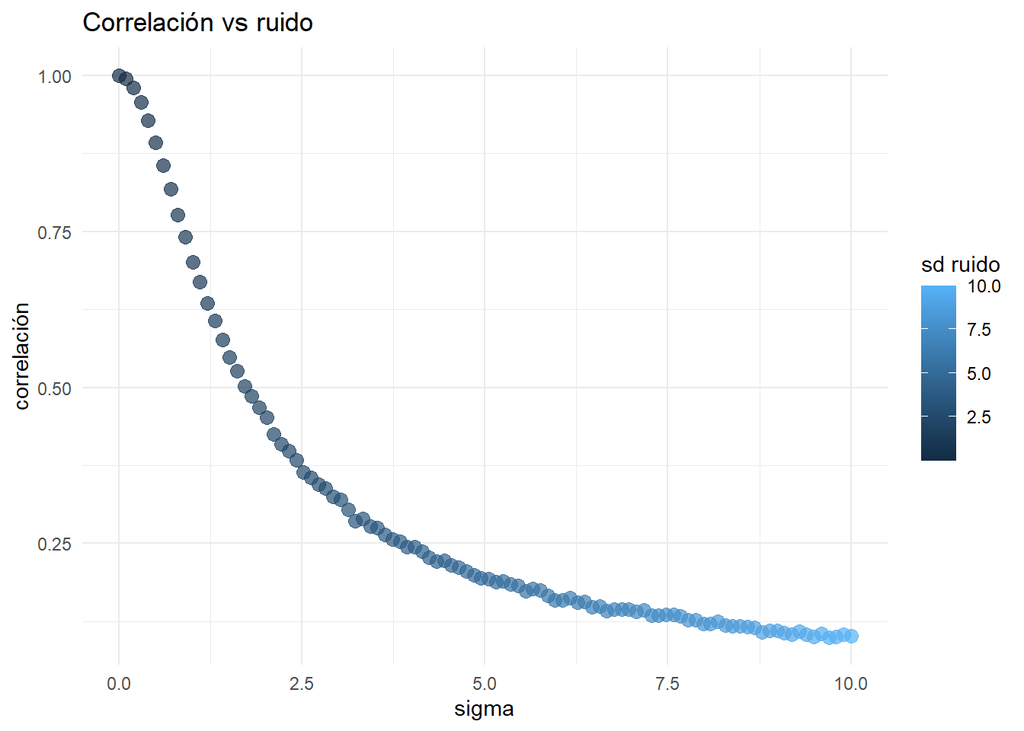

```r
set.seed(12345)
x <- rnorm(n = 1e5, mean = 0, sd = 0.5)
sigmas <- seq(0.0001, 10, l = 100)
correlations <- tibble("sigmas" = sigmas, "cor" = NA)

for (i in 1:length(sigmas)) {

  # vamos añadiendo ruido y calculamos la correlación
  y <- 2*x + rnorm(n = 1e5, mean = 0, sd = sigmas[i])
  correlations$cor[i] <- cor(x, y)

}

ggplot(correlations, aes(x = sigmas, y = cor)) +
  geom_point(aes(color = sigmas), size = 3, alpha = 0.7) +
  labs(title = "Correlación vs ruido",
       x = "sigma", y = "correlación",
       color = "sd ruido") +
  theme_minimal()
```

La **correlación captura la relación lineal** pero si entre ambas variables hay demás algo aleatorio que no podemos capturar, según **aumente la varianza del ruido, la correlación será más débil** ya que perturbará la dependencia entre ellas.

## 4 Correlación vs causalidad

Por último, vamos a mencionar un matiz importante: la idea de **causalidad**

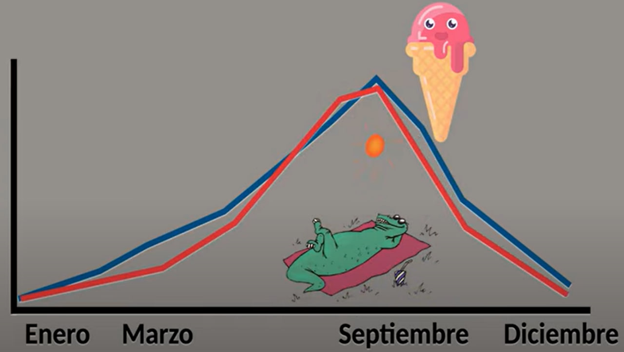

Imagina que $X$ e $Y$ fuesen variables dependientes (lineales o no) como en la imagen…**¿implicaría que el ascenso/descenso de una PROVOCA el ascenso/descenso de la otra?**

En el caso de la imagen el nivel de bronceado (X) y el consumo de helados (Y). parece que son dependientes? Pero…¿una causa la otra?

Diremos que dos variables tienen una **relación causal o de causalidad** cuando una variable es la CAUSA del comportamiento de la otra, algo que no sabremos solo con estadística (sino con conocimiento experto, en este caso de nutricionistas y médicos). Y es que, mal que nos pese a veces a los matemáticos/estadísticos/científicos de datos, **correlación NO IMPLICA causalidad** (al menos no tiene por qué)

**Otro ejemplo** podemos verlo en la siguiente gráfica que, aparentemente, nos dice que comer chocolate nos hará ganar el Nobel. Ojalá :P

[figure not shown]

Este fenómeno es conocido como **correlaciones espúreas**, y aparece cuando dos variables presentan una **relación matemática** pero sin **ningún tipo de relación causal o lógica**. Puedes ver más en https://www.tylervigen.com/spurious-correlations

Dicho patrón matemático puede deberse al mero azar o la existencia de lo que se conoce como **variables de confusión** (en el caso del helado, el verano es el que causa ambas).

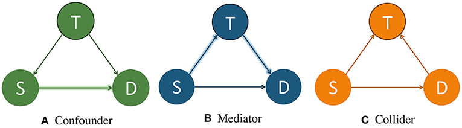

La rama que se dedica al **estudio de la causalidad**, combinando las ramas de la **estadística, filosofía, sociología y psicología** se le conoce como **inferencia causal** y es fundamental en un análisis más profundo de las relaciones entre las variables (sobre todo en campos como la economía, la psicología o la sociología).

**Recuerda**

Así que recuerda: un buen estadístico/a o científico/a de datos debe ser **humilde** en sus atribuciones. Nuestro trabajo llega hasta encontrar patrones. **Deja a otros expertos** que sean los que, con su conocimiento de la matería, atribuyan causas y consecuencias.

## 5 Caso práctico I: anscombe

En el paquete `{datasets}` se encuentra el dataset conocido como **cuarteto de Anscombe**, un dataset que cuenta en realidad con 4 conjuntos de datos.

```r
library(tidyverse)
anscombe_tb <- as_tibble(datasets::anscombe)
anscombe_tb
```

```
# A tibble: 11 × 8
      x1    x2    x3    x4    y1    y2    y3    y4
   <dbl> <dbl> <dbl> <dbl> <dbl> <dbl> <dbl> <dbl>
 1    10    10    10     8  8.04  9.14  7.46  6.58
 2     8     8     8     8  6.95  8.14  6.77  5.76
 3    13    13    13     8  7.58  8.74 12.7   7.71
 4     9     9     9     8  8.81  8.77  7.11  8.84
 5    11    11    11     8  8.33  9.26  7.81  8.47
 6    14    14    14     8  9.96  8.1   8.84  7.04
 7     6     6     6     8  7.24  6.13  6.08  5.25
 8     4     4     4    19  4.26  3.1   5.39 12.5
 9    12    12    12     8 10.8   9.13  8.15  5.56
10     7     7     7     8  4.82  7.26  6.42  7.91
11     5     5     5     8  5.68  4.74  5.73  6.89
```

Para su correcto manejo vamos a **convertirlo a tidydata**

```r
anscombe_x <-
  anscombe_tb |>
  pivot_longer(cols = x1:x4, names_to = "dataset", values_to = "x") |>
  select(-contains("y")) |>
  mutate(dataset = str_remove_all(dataset, "x"))

anscombe_y <-
  anscombe_tb |>
  pivot_longer(cols = y1:y4, names_to = "dataset", values_to = "y") |>
  select(-contains("x"), -dataset)

anscombe_tidy <-
  anscombe_x |> mutate("y" = anscombe_y$y)
anscombe_tidy
```

```
# A tibble: 44 × 3
   dataset     x     y
   <chr>   <dbl> <dbl>
 1 1          10  8.04
 2 2          10  9.14
 3 3          10  7.46
 4 4           8  6.58
 5 1           8  6.95
 6 2           8  8.14
 7 3           8  6.77
 8 4           8  5.76
 9 1          13  7.58
10 2          13  8.74
# ℹ 34 more rows
```

**¿Qué características muestrales tienen?** Para conocerlos un poco mejor vamos a **calcular** la media, varianza, desv. típica, covarianza y correlación en cada dataset

```r
anscombe_tidy |>
  summarise(mean_x = mean(x), mean_y = mean(y),
            var_x = var(x), var_y = var(y),
            sd_x = sd(x), sd_y = sd(y),
            cov = cov(x, y), cor = cor(x, y), .by = dataset)
```

```
# A tibble: 4 × 9
  dataset mean_x mean_y var_x var_y  sd_x  sd_y   cov   cor
  <chr>    <dbl>  <dbl> <dbl> <dbl> <dbl> <dbl> <dbl> <dbl>
1 1            9   7.50    11  4.13  3.32  2.03  5.50 0.816
2 2            9   7.50    11  4.13  3.32  2.03  5.5  0.816
3 3            9   7.5     11  4.12  3.32  2.03  5.50 0.816
4 4            9   7.50    11  4.12  3.32  2.03  5.50 0.817
```

Si te fijas todos los datasets tienen los **mismos momentos** muestrales, y en concreto **tienen la misma correlación** y **misma covarianza**.

**¿Serán el mismo dataset desordenado?**

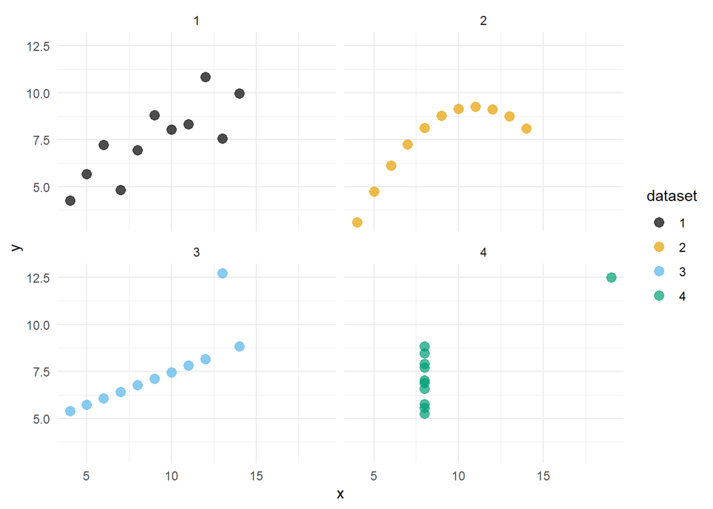

```r
ggplot(anscombe_tidy) +
  geom_point(aes(x = x, y = y, color = dataset), size = 3, alpha = 0.7) +
  ggthemes::scale_color_colorblind() +
  facet_wrap(~dataset) +
  theme_minimal()
```

Por suerte o por desgracia **no todo son matemáticas**: antes de pensar que modelo es mejor para nuestros datos, es importantísimo realizar un **análisis exploratorio** de los datos (incluyendo, por supuesto, una correcta visualización).

## 6 Caso práctico II: datasauRus

Podemos visualizarlo de manera aún más extrema con el dataset `datasaurus_dozen` del paquete `{datasauRus}` (ver más en https://www.research.autodesk.com/publications/same-stats-different-graphs/)

```r
library(datasauRus)
datasaurus_dozen |>
  summarise(mean_x = mean(x), mean_y = mean(y),
            var_x = var(x), var_y = var(y),
            sd_x = sd(x), sd_y = sd(y),
            cov = cov(x, y), cor = cor(x, y), .by = dataset)
```

```
# A tibble: 13 × 9
   dataset    mean_x mean_y var_x var_y  sd_x  sd_y   cov     cor
   <chr>       <dbl>  <dbl> <dbl> <dbl> <dbl> <dbl> <dbl>   <dbl>
 1 dino         54.3   47.8  281.  726.  16.8  26.9 -29.1 -0.0645
 2 away         54.3   47.8  281.  726.  16.8  26.9 -29.0 -0.0641
 3 h_lines      54.3   47.8  281.  726.  16.8  26.9 -27.9 -0.0617
 4 v_lines      54.3   47.8  281.  726.  16.8  26.9 -31.4 -0.0694
 5 x_shape      54.3   47.8  281.  725.  16.8  26.9 -29.6 -0.0656
 6 star         54.3   47.8  281.  725.  16.8  26.9 -28.4 -0.0630
 7 high_lines   54.3   47.8  281.  726.  16.8  26.9 -30.9 -0.0685
 8 dots         54.3   47.8  281.  725.  16.8  26.9 -27.2 -0.0603
 9 circle       54.3   47.8  281.  725.  16.8  26.9 -30.8 -0.0683
10 bullseye     54.3   47.8  281.  726.  16.8  26.9 -31.0 -0.0686
11 slant_up     54.3   47.8  281.  726.  16.8  26.9 -31.0 -0.0686
12 slant_down   54.3   47.8  281.  726.  16.8  26.9 -31.2 -0.0690
13 wide_lines   54.3   47.8  281.  726.  16.8  26.9 -30.1 -0.0666
```

De nuevo tenemos la **misma correlación** pero…¿tendrán la misma relación lineal de verdad?

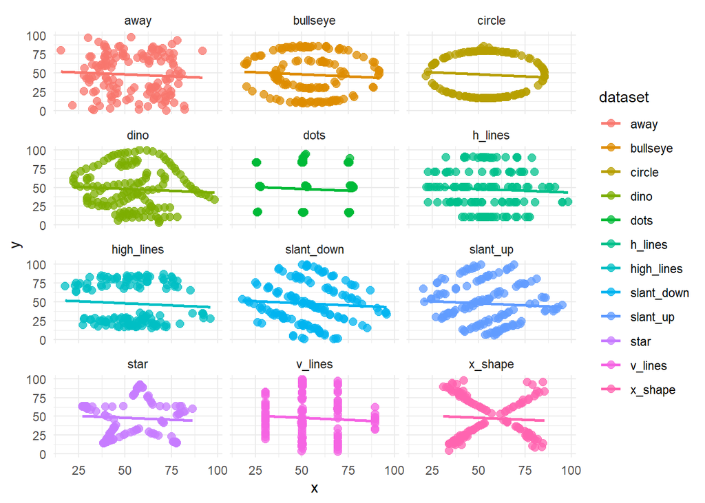

```r
ggplot(datasaurus_dozen |>
         filter(dataset != "wide_lines"),
       aes(x = x, y = y, color = dataset)) +
  geom_point(size = 2.5, alpha = 0.75) +
  geom_smooth(method = "lm", se = FALSE)  +
  facet_wrap(~dataset, ncol = 3) +
  theme_minimal()
```

**Moraleja**

Los resúmenes numéricos son eso, resúmenes, y como veremos más adelante, pueden existir distintos factores que enmascaran la verdadera relación de las variables. Por eso saber visualizar de una manera correcta es vital.

## 7 Caso práctico III: wine.csv

Vamos a poner en práctica lo aprendido con el dataset `wine.csv` disponible en el campus.

```r
datos <- read_csv(file = "./datos/wine.csv")
datos
```

```
# A tibble: 27 × 7
    Year Price WinterRain  AGST HarvestRain   Age FrancePop
   <dbl> <dbl>      <dbl> <dbl>       <dbl> <dbl>     <dbl>
 1  1952  7.50        600  17.1         160    31    43184.
 2  1953  8.04        690  16.7          80    30    43495.
 3  1955  7.69        502  17.2         130    28    44218.
 4  1957  6.98        420  16.1         110    26    45152.
 5  1958  6.78        582  16.4         187    25    45654.
 6  1959  8.08        485  17.5         187    24    46129.
 7  1960  6.52        763  16.4         290    23    46584.
 8  1961  8.49        830  17.3          38    22    47128.
 9  1962  7.39        697  16.3          52    21    48089.
10  1963  6.71        608  15.7         155    20    48799.
# ℹ 17 more rows
```

El conjunto de datos está formado por 27 observaciones (cosechas de vino rojo Burdeos) y **7 variables**

- `Year`, `Age`: año de la cosecha y número de años en barrica.
- `Price`: precio en 1990-1991 de cada cosecha (en **escala log**)
- `WinterRain`: lluvia (en mm) que cayó ese año en invierno.
- `AGST`: crecimiento medio de la temperatura (en grados Celsius) durante la temporada.
- `HarvestRain`: lluvia (en mm) que cayó ese año durante la cosecha.
- `FrancePop`: población (miles de habitantes) de Francia.

Puedes ver más en detalles en https://doi.org/10.1080/09332480.1995.10542468

Si el objetivo fuese **predecir el precio**, $Y = precio$, con una sola predictora $X$, ¿cuál tendríamos que elegir? Si el modelo lineal, parece ya claro que deberemos elegir a priori aquella con **mayor correlación lineal (en valor absoluto)**. Pero como hemos visto con los ejemplos, a veces los resúmenes numéricos pueden engañarnos así que lo primero que haremos será realizar un **análisis exploratorio**.

### 7.1 Análisis exploratorio

Algunas de las primeras preguntas que podemos hacernos son:

- ¿Las variables son **numéricas (continuas)**?
- ¿Tienen **problemas de rango** (por ejemplo, pesos negativos)? ¿Tienen datos ausentes?

Para responder a dichas preguntas lo más sencillos es hacer uso de la función `skim()` del paquete `{skimr}`

```r
library(skimr)
datos |> skim()
```

Data summary

| Name | datos |
| --- | --- |
| Number of rows | 27 |
| Number of columns | 7 |
| _______________________ |  |
| Column type frequency: |  |
| numeric | 7 |
| ________________________ |  |
| Group variables | None |

**Variable type: numeric**

| skim_variable | n_missing | complete_rate | mean | sd | p0 | p25 | p50 | p75 | p100 | hist |
| --- | --- | --- | --- | --- | --- | --- | --- | --- | --- | --- |
| Year | 0 | 1 | 1966.81 | 8.25 | 1952.00 | 1960.50 | 1967.00 | 1973.50 | 1980.00 | ▅▇▇▇▇ |
| Price | 0 | 1 | 7.04 | 0.63 | 6.20 | 6.51 | 6.98 | 7.44 | 8.49 | ▇▅▆▂▂ |
| WinterRain | 0 | 1 | 608.41 | 129.03 | 376.00 | 543.50 | 600.00 | 705.50 | 830.00 | ▃▃▇▃▃ |
| AGST | 0 | 1 | 16.48 | 0.66 | 14.98 | 16.15 | 16.42 | 17.01 | 17.65 | ▂▃▇▃▅ |
| HarvestRain | 0 | 1 | 144.81 | 73.07 | 38.00 | 88.00 | 123.00 | 185.50 | 292.00 | ▇▇▇▁▅ |
| Age | 0 | 1 | 16.19 | 8.25 | 3.00 | 9.50 | 16.00 | 22.50 | 31.00 | ▇▇▇▇▅ |
| FrancePop | 0 | 1 | 50085.44 | 3793.00 | 43183.57 | 46856.00 | 50650.41 | 53511.21 | 55110.24 | ▃▃▅▅▇ |

En este caso **no tenemos ausentes ni problemas de codificación**

Profundizando un poco podemos preguntarnos…

- ¿Cómo se **distribuyen las variables**?
- ¿Hay **datos atípicos**?

Para ello podemos empezar **visualizando la distribución de cada variable** haciendo uso de densidades, histogramas y/o boxplots (por ejemplo), pero si queremos ahorrar tiempo en visualizar convertimos nuestro dataset en **tidydata**

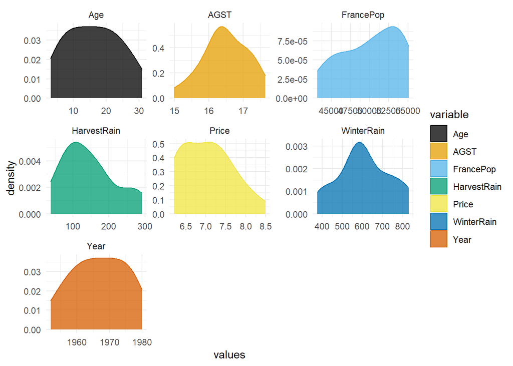

```r
datos_tidy <-
  datos |>
  pivot_longer(cols = everything(), names_to = "variable", values_to = "values")

ggplot(datos_tidy, aes(x = values)) +
  geom_density(aes(color = variable, fill = variable),
               alpha = 0.75) +
  ggthemes::scale_color_colorblind() +
  ggthemes::scale_fill_colorblind() +
  facet_wrap(~variable, scales = "free") +
  theme_minimal()
```

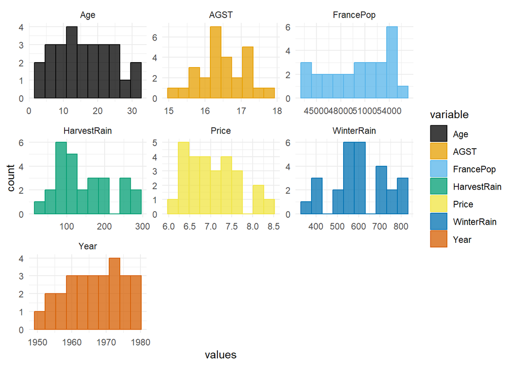

```r
ggplot(datos_tidy, aes(x = values)) +
  geom_histogram(aes(color = variable, fill = variable),
               alpha = 0.75, bins = 10) +
  ggthemes::scale_color_colorblind() +
  ggthemes::scale_fill_colorblind() +
  facet_wrap(~variable, scales = "free") +
  theme_minimal()
```

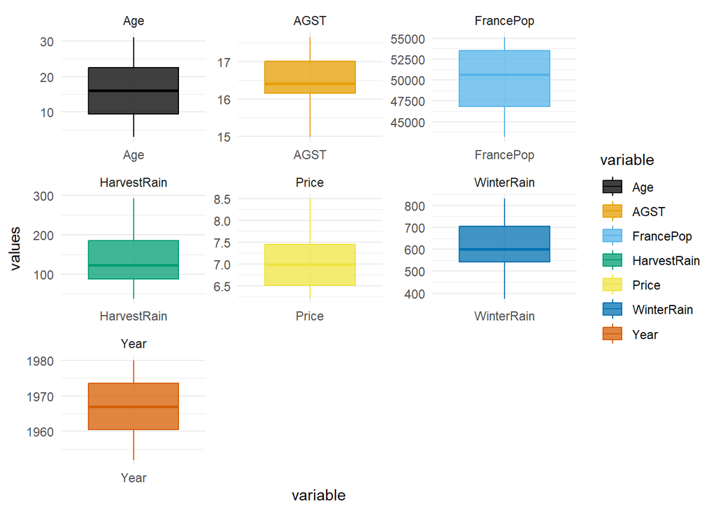

```r
ggplot(datos_tidy, aes(y = values, x = variable)) +
  geom_boxplot(aes(color = variable, fill = variable),
               alpha = 0.75) +
  ggthemes::scale_color_colorblind() +
  ggthemes::scale_fill_colorblind() +
  facet_wrap(~variable, scales = "free") +
  theme_minimal()
```

**No se aprecian valores atípicos** (al menos respecto a los percentiles)

Podemos incluso gráficar todos los scatter plot sin transformar los datos con `facet_matrix()` del paquete `{ggforce}`

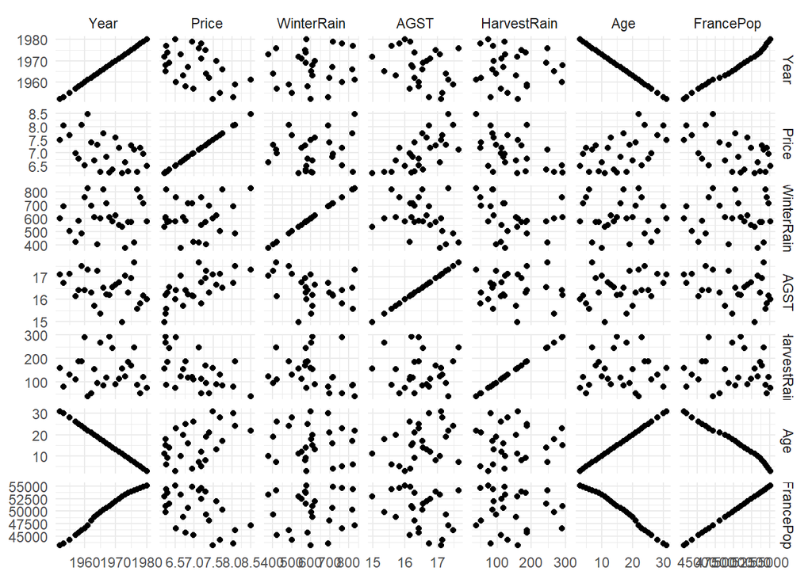

```r
library(ggforce)
ggplot(datos) +
  geom_point(aes(x = .panel_x, y = .panel_y)) +
  facet_matrix(vars(everything())) +
  ggthemes::scale_color_colorblind() +
  ggthemes::scale_fill_colorblind() +
  theme_minimal()
```

Podemos también visualizar con un **scatter plot** todas las variables y además sus correlaciones, con el paquete `{GGally}` y la función `ggpairs(), sin necesidad de convertir a tidydata.

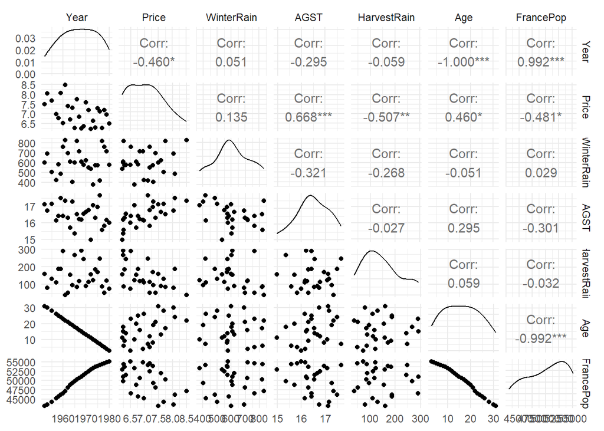

```r
library(GGally)
ggpairs(datos) +
  theme_minimal()
```

### 7.2 Análisis de dependencia

Tras una primera visualización de los datos, de cada variable por separado, nuestro objetivo real sería responder a

- ¿Qué **predictora está más correlacionada (linealmente) con la variable objetivo** a predecir? ¿Existe otro tipo de dependencia ?
- ¿Cómo se **relacionan las predictoras** entre sí? ¿Están correlacionadas? Este último paso será crucial en el **contexto multivariante** pero en este caso simplemente vamos a ver como se relacionan linealmente las predictoras entre sí (por saber como se haría), y cuál de ellas es la **más adecuada para predecir linealmente** `precio`

El primer paso es la **matriz de correlaciones** con la función `correlate()` del paquete `{corrr}`

```r
datos |>
  correlate() |>
  fashion()
```

```
Correlation computed with
• Method: 'pearson'
• Missing treated using: 'pairwise.complete.obs'
```

```
         term  Year Price WinterRain AGST HarvestRain   Age FrancePop
1        Year        -.46        .05 -.29        -.06 -1.00       .99
2       Price  -.46              .13  .67        -.51   .46      -.48
3  WinterRain   .05   .13            -.32        -.27  -.05       .03
4        AGST  -.29   .67       -.32             -.03   .29      -.30
5 HarvestRain  -.06  -.51       -.27 -.03               .06      -.03
6         Age -1.00   .46       -.05  .29         .06            -.99
7   FrancePop   .99  -.48        .03 -.30        -.03  -.99
```

Podemos **visualizar dichas correlaciones con un grafo** con `network_plot()`

```r
datos |>
  correlate() |>
  network_plot(min_cor = 0.5)
```

[output not shown]

En cuando a la **dependencia entre predictoras**, las variables `Age`, `Year` y `FrancePop` presentan la misma información. Si queremos centrarnos solo en las variables vs la predictora, podemos hacer `focus()` en ella

```r
datos |>
  correlate() |>
  corrr::focus(Price)
```

```
Correlation computed with
• Method: 'pearson'
• Missing treated using: 'pairwise.complete.obs'
```

```
# A tibble: 6 × 2
  term         Price
  <chr>        <dbl>
1 Year        -0.460
2 WinterRain   0.135
3 AGST         0.668
4 HarvestRain -0.507
5 Age          0.460
6 FrancePop   -0.481
```

**Respecto a Y**, las predictoras con mayor correlación lineal son `AGST` (más calor, menos cosechas, sube el precio) y `HarvestRain` (más lluvias, más cosechas, baja el precio, ¡el signo importa!)

También podemos usar `corrplot()` del paquete `{corrplot}`, al que le pasamos una matriz de correlaciones clásica y nos la **visualiza**.

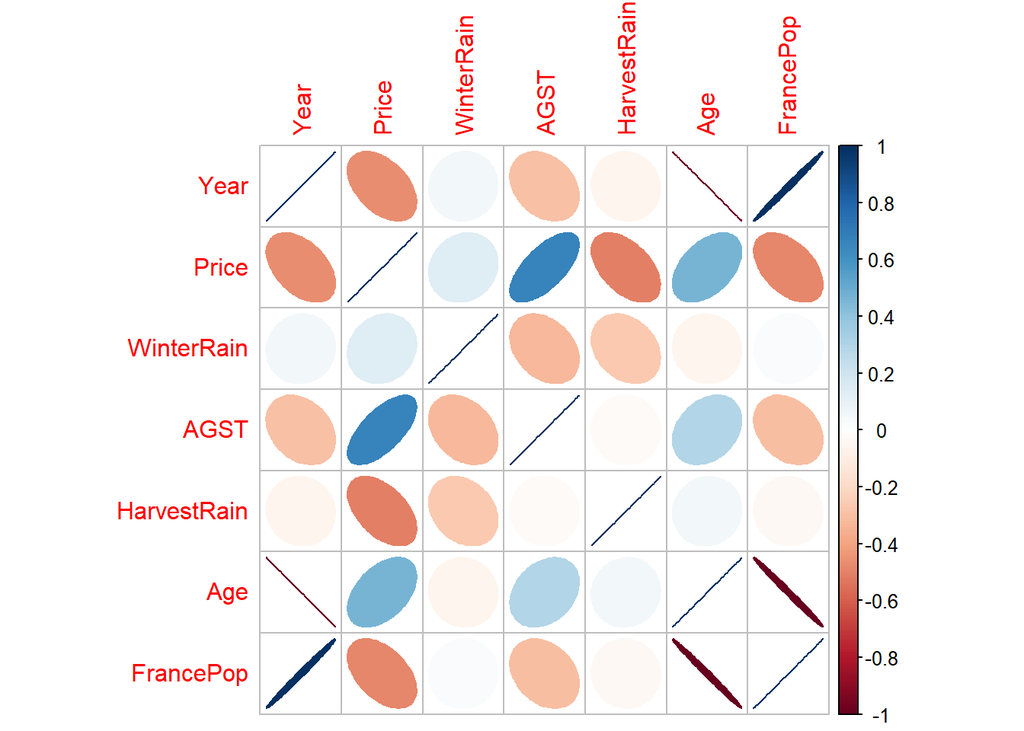

```r
library(corrplot)
datos |>
  cor() |>
  corrplot(method = "ellipse")
```

Otra opción es **visualizar con un scatter plots todas las predictoras vs Y**, pivotando antes nuestro dataset (solo pivotamos las predictoras)

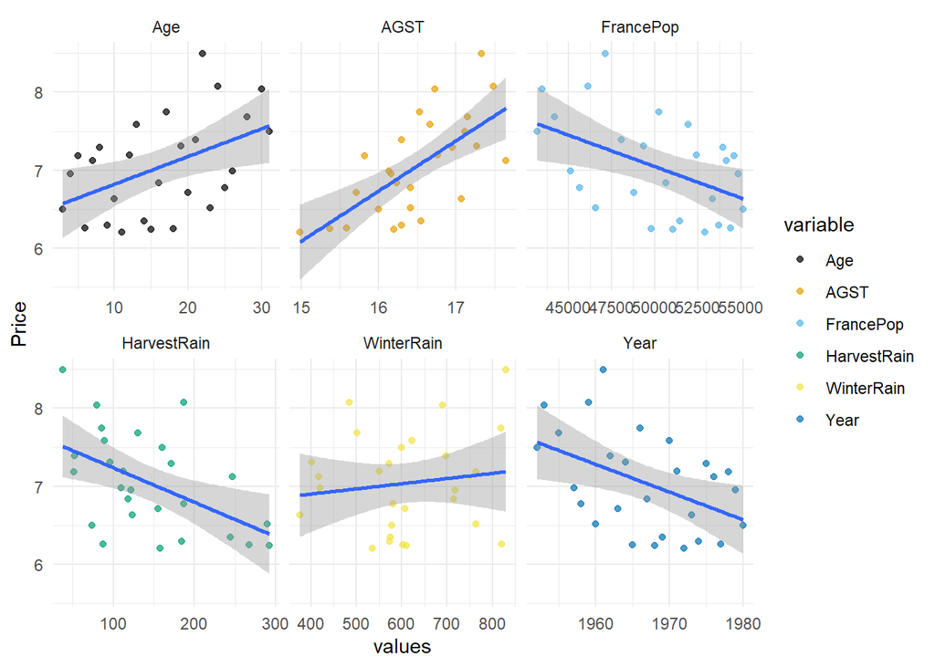

```r
datos_tidy <-
  datos |> pivot_longer(cols = -Price, names_to = "variable",
                        values_to = "values")
ggplot(datos_tidy, aes(x = values, y = Price)) +
  geom_point(aes(color = variable), alpha = 0.7) +
  geom_smooth(method = "lm") +
  ggthemes::scale_color_colorblind() +
  facet_wrap(~variable, scales = "free_x") +
  theme_minimal()
```

No solo comprobamos que las rectas con más pendiente son `AGST` y `HarvestRain`, además los puntos **parecen poder ajustarse a una recta sin otro patrón identificable**. Esto es importante hacerlo ya que debemos **descartar posibles correlaciones espúreas** (ver ejemplo datasaurus)

Por lo tanto parece claro: la mejor covariable para predecir linealmente el precio sería `AGST` (en sentido positivo) y `HarvestRain` (en sentido negativo)